# dn3_Matjaz

Urban Matjaž

2025-03-07

# 3. DOMAČA NALOGA

# 1. naloga

```r
getData = function(beta_3, n = 100, beta_0 = 10, beta_1 = 0.5, beta_2 = 0.15, sigma = 10) {
  set.seed(1)
  x1 = runif(n, 50, 100)
  x2 = runif(n, 50, 100)

  eps = rnorm(n, mean = 0, sd = sigma)
  y = beta_0 + beta_1 * x1 + beta_2 * x2 + beta_3 * x1 * x2 + eps

  data.frame(x1 = x1, x2 = x2, y = y)
}


beta_3_values = c(0, 0.05, 0.5)
data_list = lapply(beta_3_values, getData)
```

```r
data_1 <- data_list[[1]]
model_1 <- lm(y ~ x1 + x2, data = data_1)

par(mfrow = c(2, 2))
```

# Model brez interakcije

```r
par(mfrow = c(2, 2))
summary(model_1)
```

```
##
## Call:
## lm(formula = y ~ x1 + x2, data = data_1)
##
## Residuals:
##     Min      1Q  Median      3Q     Max
## -18.579  -6.167  -1.432   5.352  23.318
##
## Coefficients:
##             Estimate Std. Error t value Pr(>|t|)
## (Intercept) 10.45539    7.73475   1.352   0.1796
## x1           0.48615    0.07269   6.688 1.45e-09 ***
## x2           0.15287    0.07156   2.136   0.0352 *
## ---
## Signif. codes:  0 '***' 0.001 '**' 0.01 '*' 0.05 '.' 0.1 ' ' 1
##
## Residual standard error: 9.675 on 97 degrees of freedom
## Multiple R-squared:  0.3392, Adjusted R-squared:  0.3256
## F-statistic:  24.9 on 2 and 97 DF,  p-value: 1.875e-09
```

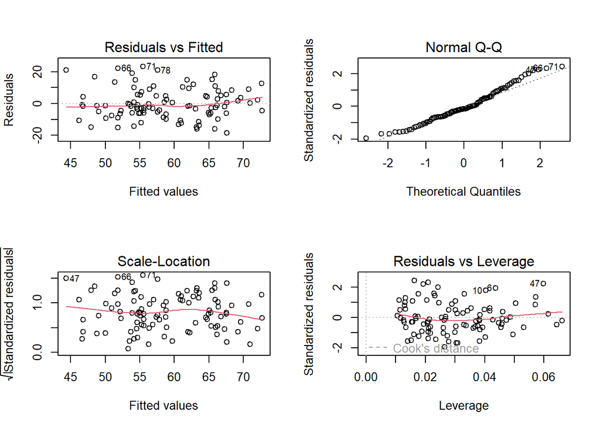

```r
plot(model_1)
```

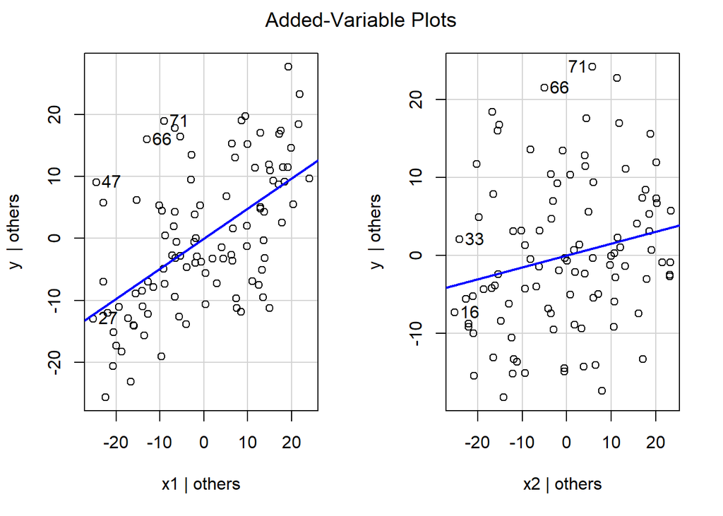

```r
avPlots(model_1)
```

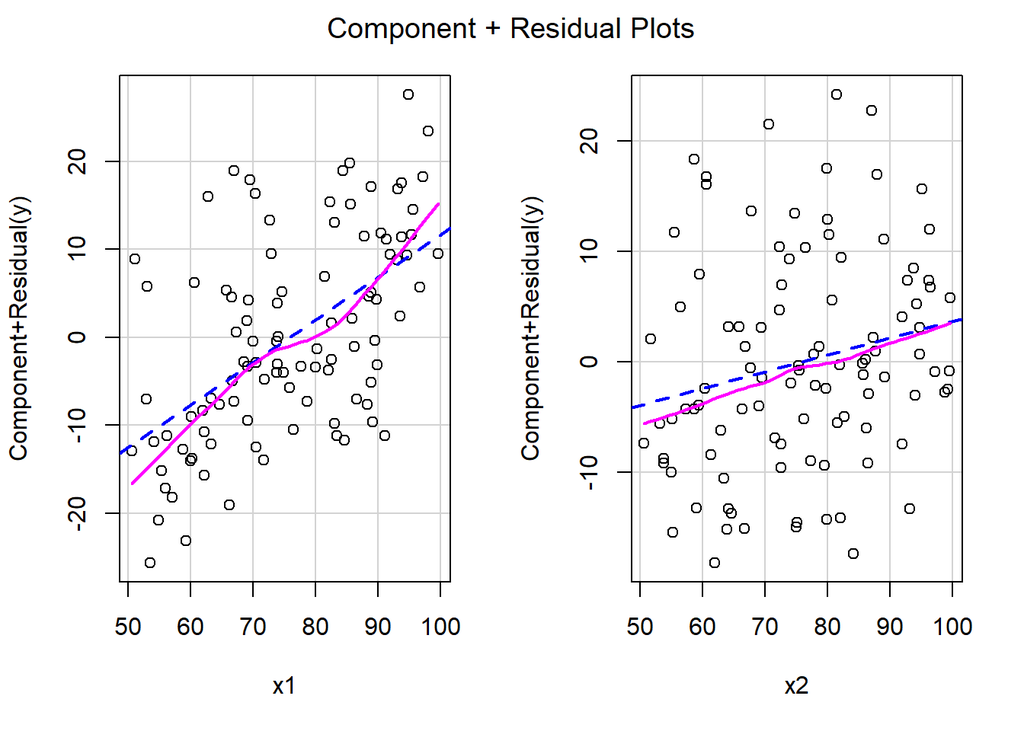

```r
crPlots(model_1)
```

Model dobro sledi predpostavkam, vendar se pojavljajo rahle nelinearnosti pri x1 (to lahkjo razberemo iz crPlot-a), kar pomeni, da bi lahko interakcijski člen izboljšal ujemanje modela.

```r
data_2 <- data_list[[2]]
model_2 <- lm(y ~ x1 * x2, data = data_2)
data_3 <- data_list[[3]]
model_3 <- lm(y ~ x1 * x2, data = data_3)
```

# model z interakcijo beta_3 = 0.05

```r
par(mfrow = c(2, 2))
summary(model_2)
```

```
##
## Call:
## lm(formula = y ~ x1 * x2, data = data_2)
##
## Residuals:
##     Min      1Q  Median      3Q     Max
## -19.112  -6.144  -1.061   5.678  23.742
##
## Coefficients:
##              Estimate Std. Error t value Pr(>|t|)
## (Intercept) 49.681855  34.461165   1.442    0.153
## x1          -0.009106   0.430192  -0.021    0.983
## x2          -0.359354   0.444339  -0.809    0.421
## x1:x2        0.056461   0.005532  10.207   <2e-16 ***
## ---
## Signif. codes:  0 '***' 0.001 '**' 0.01 '*' 0.05 '.' 0.1 ' ' 1
##
## Residual standard error: 9.657 on 96 degrees of freedom
## Multiple R-squared:  0.9866, Adjusted R-squared:  0.9862
## F-statistic:  2363 on 3 and 96 DF,  p-value: < 2.2e-16
```

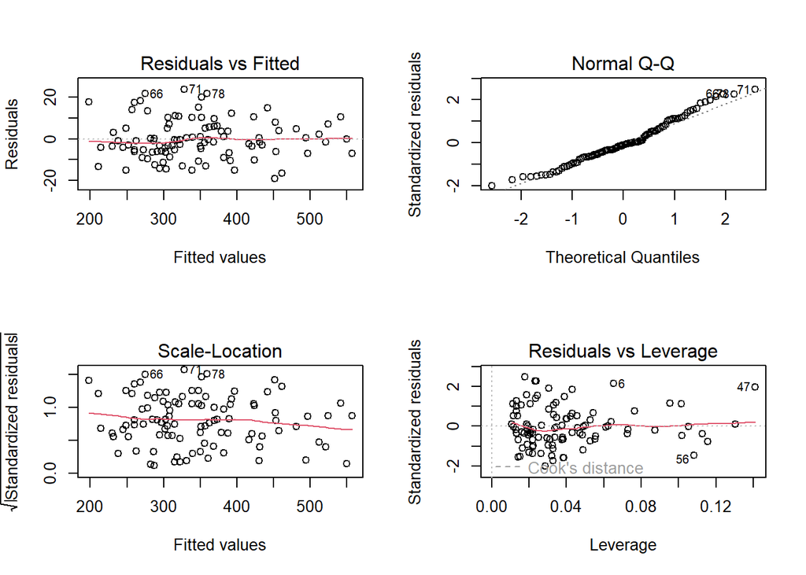

```r
plot(model_2)
```

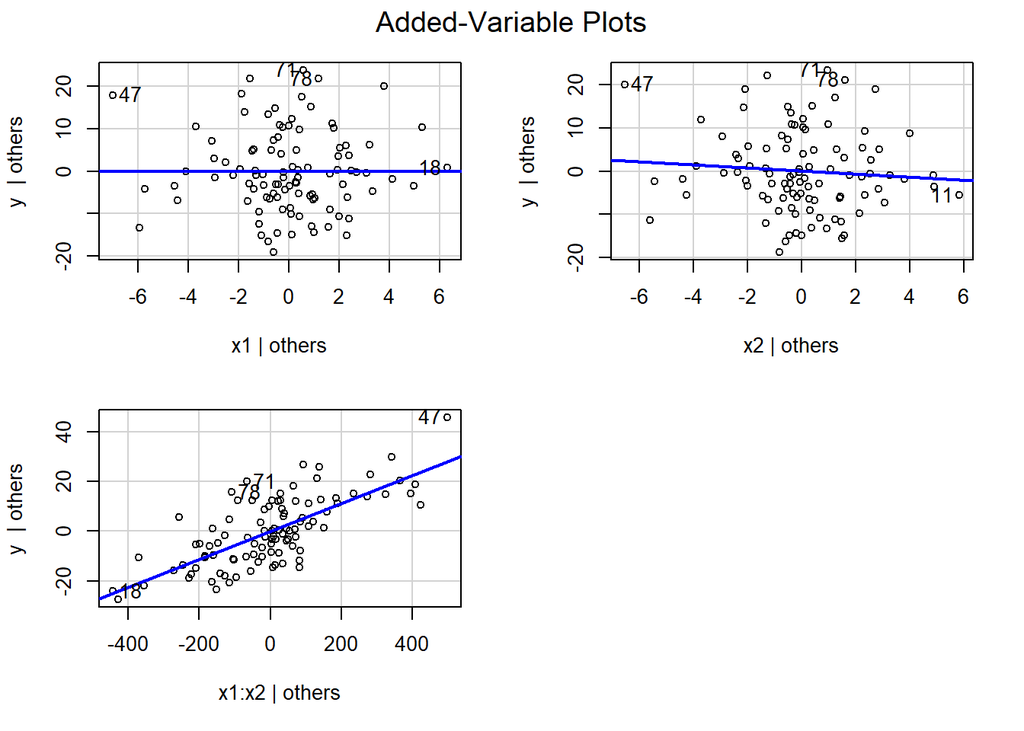

```r
avPlots(model_2)
```

Vidimo, da so predpostavke modela izpolnjene, torej ni izrazite heteroskedastičnosti (ob večjih vrednostih, je variabilnost ostankov sicer malo manjša ampak ne preveč). Prav tako vidimo da je vpliv neodvisnih spremenljivk linearen.

# model z interakcijo beta_3 = 0.5

```r
par(mfrow = c(2, 2))
summary(model_3)
```

```
##
## Call:
## lm(formula = y ~ x1 * x2, data = data_3)
##
## Residuals:
##     Min      1Q  Median      3Q     Max
## -19.112  -6.144  -1.061   5.678  23.742
##
## Coefficients:
##              Estimate Std. Error t value Pr(>|t|)
## (Intercept) 49.681855  34.461165   1.442    0.153
## x1          -0.009106   0.430192  -0.021    0.983
## x2          -0.359354   0.444339  -0.809    0.421
## x1:x2        0.506461   0.005532  91.554   <2e-16 ***
## ---
## Signif. codes:  0 '***' 0.001 '**' 0.01 '*' 0.05 '.' 0.1 ' ' 1
##
## Residual standard error: 9.657 on 96 degrees of freedom
## Multiple R-squared:  0.9998, Adjusted R-squared:  0.9998
## F-statistic: 2.051e+05 on 3 and 96 DF,  p-value: < 2.2e-16
```

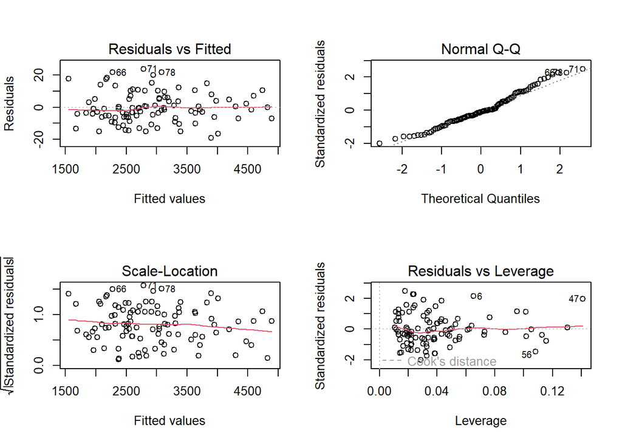

```r
plot(model_3)
```

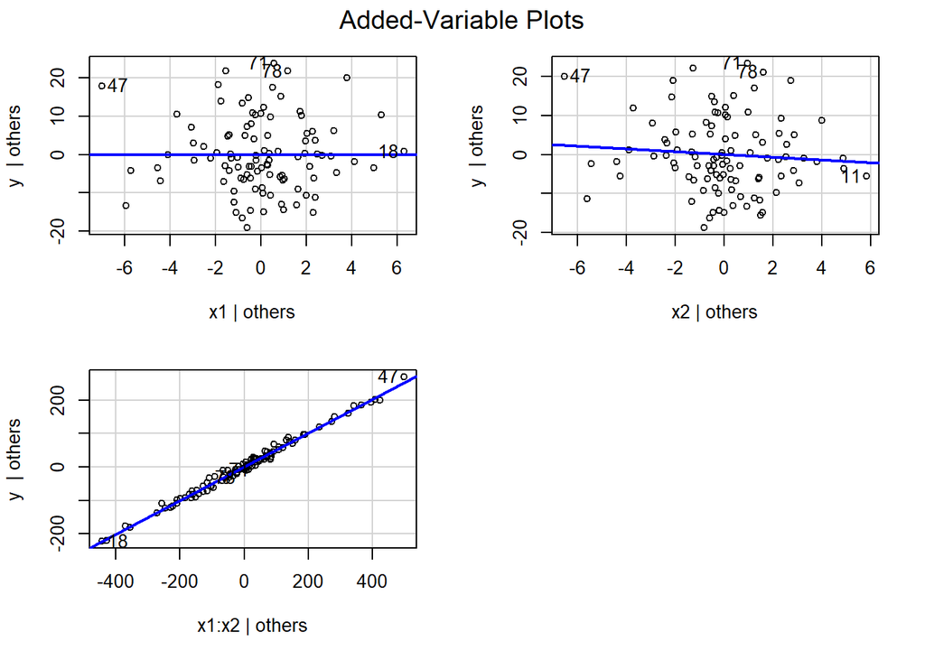

```r
avPlots(model_3)
```

Podatki so homoskedastični, q-q plot kaže na odstopanje od normalnosti na repih, Kaže se linearnost.

# 2. naloga

```r
data_snowgeese <- read.table("SNOWGEESE.txt", header = TRUE)
```

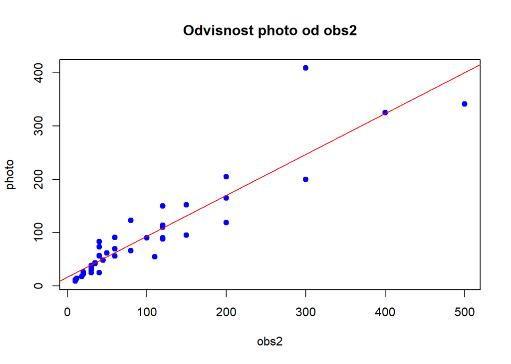

```r
par(mfrow = c(1, 1))
plot(data_snowgeese$obs2, data_snowgeese$photo,
     xlab = "obs2",
     ylab = "photo",
     main = "Odvisnost photo od obs2",
     pch = 19, col = "blue")
abline(lm(photo ~ obs2, data = data_snowgeese), col = "red")
```

Model se mi ne zdi primeren zaradi osamelcev.

```r
model.goske <- lm(photo ~ obs2, data = data_snowgeese)

summary(model.goske)
```

```
##
## Call:
## lm(formula = photo ~ obs2, data = data_snowgeese)
##
## Residuals:
##     Min      1Q  Median      3Q     Max
## -58.698 -12.007  -3.071   7.692 162.116
##
## Coefficients:
##             Estimate Std. Error t value Pr(>|t|)
## (Intercept) 16.16428    6.82973   2.367   0.0225 *
## obs2         0.76907    0.04835  15.905   <2e-16 ***
## ---
## Signif. codes:  0 '***' 0.001 '**' 0.01 '*' 0.05 '.' 0.1 ' ' 1
##
## Residual standard error: 33.87 on 43 degrees of freedom
## Multiple R-squared:  0.8547, Adjusted R-squared:  0.8513
## F-statistic:   253 on 1 and 43 DF,  p-value: < 2.2e-16
```

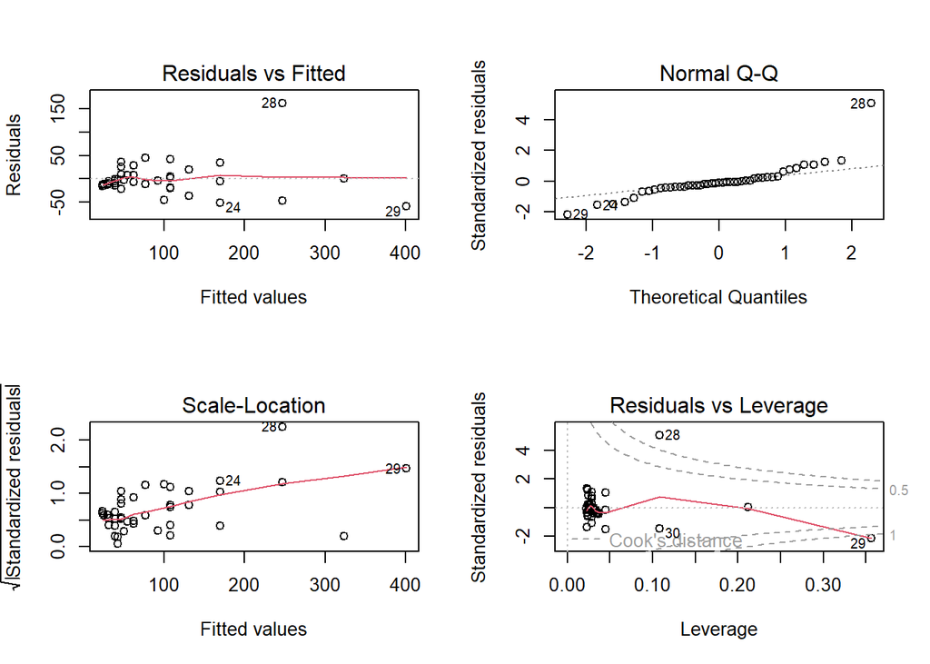

```r
par(mfrow = c(2, 2))
plot(model.goske)
```

Vidimo, da so predpostavke modela kršene. Imamo heteroskedastičnost, nelinearno odvisnost med spremenljivkami in tudi ostanki niso porazdeljeni normalno.

```r
model.goske.log <- lm(log(photo) ~ log(obs2), data = data_snowgeese)
```

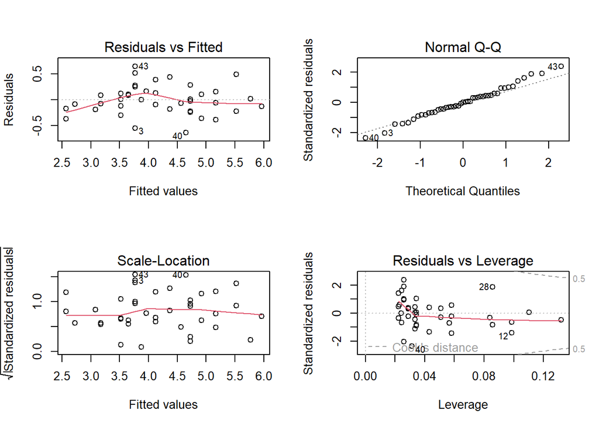

```r
par(mfrow = c(2, 2))
plot(model.goske.log)
```

Še vedno prihaja do malo heterskedastičnosti (variabilnost je nižja pri nižjih vrednostih), nelinearnost v modelu smo z logaritmiranjem odpravili, prav tako so se standardizirani ostanki približali normalni porazdelitvi.

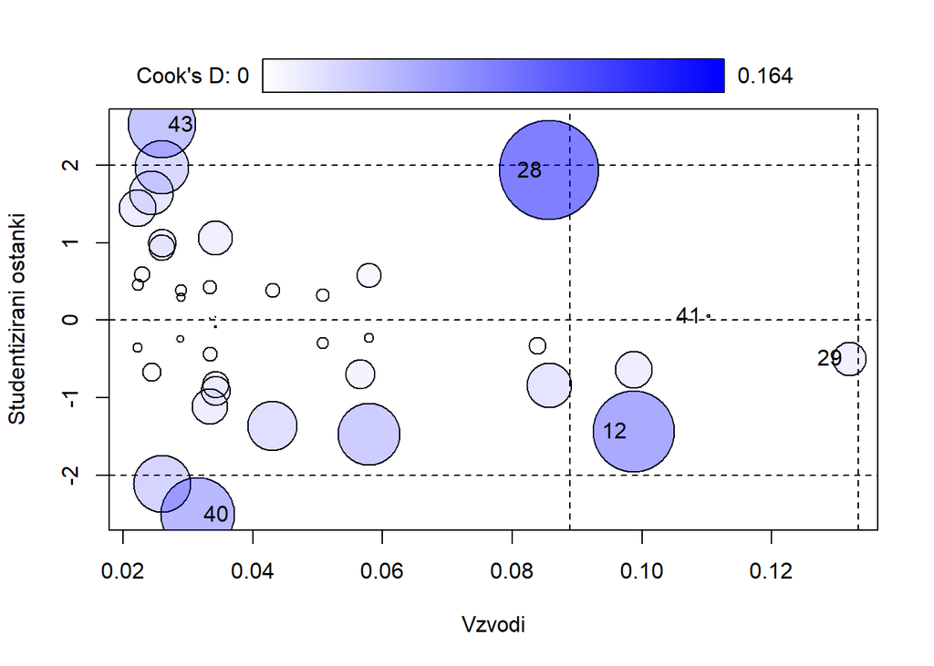

```
##        StudRes        Hat        CookD
## 12 -1.43445737 0.09868981 0.1099487455
## 28  1.93149133 0.08566575 0.1643307309
## 29 -0.49465222 0.13194317 0.0189280161
## 40 -2.50531931 0.03143969 0.0907359424
## 41  0.05475026 0.11017841 0.0001899871
## 43  2.52301542 0.02596203 0.0754231054
```

```r
par(mfrow = c(1, 1))
influencePlot(model.goske.log,
              id = list(method = "noteworthy", n = 2, cex = 1, location = "lr"),
              xlab = "Vzvodi", ylab = "Studentizirani ostanki")
```

```r
outlierTest(model.goske.log)
```

```
## No Studentized residuals with Bonferroni p < 0.05
## Largest |rstudent|:
##    rstudent unadjusted p-value Bonferroni p
## 43 2.523015           0.015509       0.6979
```

Enota 43 ima največji potencial, da bi bila regresijski osamelec, vendar po opravljenem testu vidimo, da ni. Bonferonijeva p vrednost je večja od 0,05.

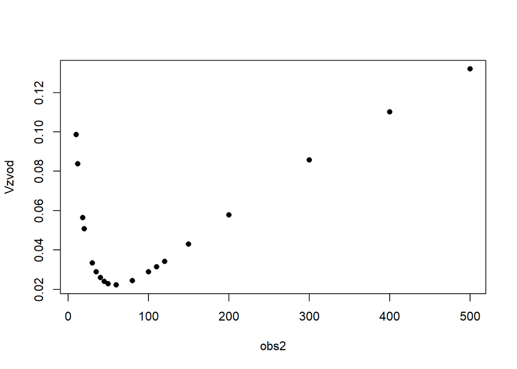

```r
plot(data_snowgeese$obs2, hatvalues(model.goske.log), pch = 16,
xlab = c("obs2"), ylab = c("Vzvod"))
```

```r
vplivne = lm.influence(model.goske.log)
names(vplivne)
```

```
## [1] "hat"          "coefficients" "sigma"        "wt.res"
```

```r
sort(vplivne$hat, decreasing = TRUE)[1:4] # 4 točke z največjimi vzvodi
```

```
##         29         41         12         19
## 0.13194317 0.11017841 0.09868981 0.09868981
```

```r
summary(model.goske.log)
```

```
##
## Call:
## lm(formula = log(photo) ~ log(obs2), data = data_snowgeese)
##
## Residuals:
##      Min       1Q   Median       3Q      Max
## -0.64179 -0.17040 -0.00229  0.12536  0.64756
##
## Coefficients:
##             Estimate Std. Error t value Pr(>|t|)
## (Intercept)  0.57016    0.17970   3.173  0.00279 **
## log(obs2)    0.86778    0.04285  20.252  < 2e-16 ***
## ---
## Signif. codes:  0 '***' 0.001 '**' 0.01 '*' 0.05 '.' 0.1 ' ' 1
##
## Residual standard error: 0.2758 on 43 degrees of freedom
## Multiple R-squared:  0.9051, Adjusted R-squared:  0.9029
## F-statistic: 410.1 on 1 and 43 DF,  p-value: < 2.2e-16
```

Če se obs2 poveča za 1% se bo photo povečal za 0,87%.

Z izbranim modelom torej log(obs2) pojasnimo približno 90% variabilnosti log(photo).

```r
exp(confint(model.goske.log)[1,])
```

```
##    2.5 %   97.5 %
## 1.230926 2.541003
```

```r
exp(confint(model.goske.log)[2,])
```

```
##    2.5 %   97.5 %
## 2.184447 2.596565
```

S 95% gotovostjo lahko trdimo, da ko je vrednost obs2 = 1, se vrednost photo nahaja med 1.231 in 2.541.